# Plate Detection

## Part 1 - Detect license plates

```python
cd C:/Users/Daniel/Desktop/New Folder
```

```
C:\Users\Daniel\Desktop\New Folder
```

```python
import cv2
import os
import numpy as np
from random import shuffle
import imutils
import matplotlib.pyplot as plt
from skimage import data, color, exposure
from sklearn import svm
from scipy import ndimage, misc
from sklearn.metrics import classification_report
from sklearn.metrics import confusion_matrix
%matplotlib inline
```

#### Method to grab folder images

```python
def getImgFolder(folder):
    images = []
    for root, dirnames, filenames in os.walk(folder):
        for filename in filenames:
            filepath = os.path.join(root, filename)
            image = ndimage.imread(filepath)
            images.append(image)
    return images
```

#### We're using 126 positive images of license plates and 325 negative images collected from Mark's sun_images and various partial license plate pictures. These pictures will help train our SVM to learn the patterns we want and don't want.

```python
pimages = getImgFolder('plates')
pimages = pimages
print(len(pimages), "pimages")
```

```
126 pimages
```

```python
nimages = getImgFolder('negatives')
partial_images = getImgFolder('partials')
nimages = nimages + partial_images
nimages = [x[1] for x in nimages]
print(len(nimages), "nimages")
```

```
325 nimages
```

#### HOG class setup using 16x16 block normalization with 8x8 cell size

```python
minDim = 80
blockSize = (16,16)
blockStride = (8,8)
cellSize = (8,8)
nbins = 9
dims = (minDim, minDim)

hog = cv2.HOGDescriptor(dims, blockSize, blockStride, cellSize, nbins)
```

#### Get HOG from our images

```python
def getFeaturesWithLabel(imageData, hog, dims, label):
    data = []
    for img in imageData:
        img = cv2.resize(img, dims)
        feat = hog.compute(img)
        data.append((feat, label))
    return data
```

#### Shuffle our pdata and ndata. Then train

```python
pdata = getFeaturesWithLabel(pimages, hog, dims, 1)
ndata = getFeaturesWithLabel(nimages, hog, dims, 0)
data = pdata + ndata
shuffle(data)
feat, labels = map(list, zip(*data))
feat = [x.flatten() for x in feat]
sample_size = len(feat)

train_size = int(round(0.8*sample_size))
train_feat = np.array(feat[:train_size], np.float32)
test_feat = np.array(feat[train_size: sample_size], np.float32)
train_label = np.array(labels[:train_size])
test_label = np.array(labels[train_size:sample_size])
```

#### SVM - Create, train, display accuracy, and confusion matrix

```python
svm = svm.SVC(kernel='linear', C = 1.0, probability=True)
svm.fit(train_feat, train_label)
```

```
SVC(C=1.0, cache_size=200, class_weight=None, coef0=0.0,
  decision_function_shape=None, degree=3, gamma='auto', kernel='linear',
  max_iter=-1, probability=True, random_state=None, shrinking=True,
  tol=0.001, verbose=False)
```

```python
print(svm.score(train_feat, train_label))
```

```
1.0
```

```python
print("tscore ", svm.score(test_feat, test_label))
y_pred = svm.predict(test_feat)
print(classification_report(test_label, y_pred))
```

```
tscore  1.0
             precision    recall  f1-score   support

          0       1.00      1.00      1.00        60
          1       1.00      1.00      1.00        30

avg / total       1.00      1.00      1.00        90
```

```python
confusion_matrix(y_pred, test_label)
```

```
array([[60,  0],
       [ 0, 30]])
```

#### Now we can test a image our SVM hasn't seen

#### First, make sure our picture is scaled correctly.

```python
def resize(img, scale):
    return cv2.resize(img, (int(img.shape[1]*scale), int(img.shape[0]*scale)))
```

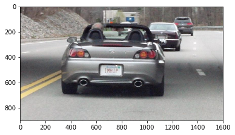

```python
im = cv2.imread("15.jpg")
if im.shape[0] > 800:
    scale = 800/im.shape[0]
else: scale = 2
im = resize(im, scale)

plt.imshow(cv2.cvtColor(im, cv2.COLOR_BGR2RGB))
plt.show()
```

#### By cropping the section our SVM thought was likely a license plate, we furthur filtered out noise by requiring the cropped image to be a width/height > 1.3 and < 2.4. This significantly reduced hit images that wasn't shaped similarly to license plates.

```python
def preprocess(image, lower, upper):
    lower = np.array(lower, dtype="uint8")
    upper = np.array(upper, dtype="uint8")
    mask = cv2.inRange(image, lower, upper)
    output = cv2.bitwise_and(image, image, mask = mask)
    return output, mask
```

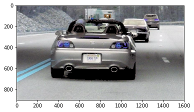

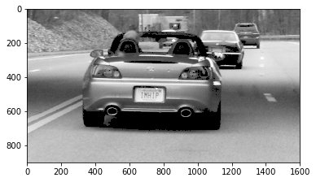

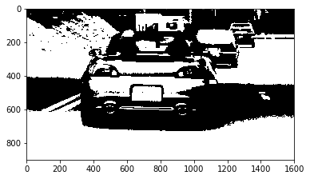

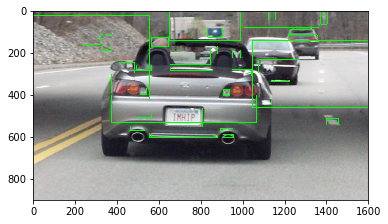

```
[ 0.14195663  0.85804337]
[ 0.04153395  0.95846605]
[ 0.03518341  0.96481659]
[ 0.15944392  0.84055608]
[ 0.06619857  0.93380143]
[ 0.10223601  0.89776399]
[ 0.08573505  0.91426495]
[ 0.00648869  0.99351131]
[ 0.05615993  0.94384007]
[ 0.11985195  0.88014805]
[ 0.05967112  0.94032888]
[ 0.0689651  0.9310349]
[ 0.08907978  0.91092022]
[ 0.079895  0.920105]
[ 0.0198312  0.9801688]
[ 0.27851249  0.72148751]
[ 0.25349959  0.74650041]
[ 0.12227205  0.87772795]
[ 0.1330365  0.8669635]
[ 0.13968094  0.86031906]
[ 0.35391356  0.64608644]
[ 0.12315247  0.87684753]
[ 0.07158405  0.92841595]
[ 0.14448335  0.85551665]
[ 0.01226948  0.98773052]
[ 0.18088679  0.81911321]
[ 0.06784582  0.93215418]
[ 0.02591665  0.97408335]
[ 0.13043811  0.86956189]
[ 0.2587402  0.7412598]
[ 0.08264362  0.91735638]
[ 0.20550582  0.79449418]
[ 0.31333109  0.68666891]
[ 0.29818885  0.70181115]
[ 0.01954191  0.98045809]
[ 0.11858781  0.88141219]
5
```

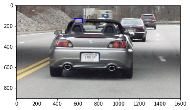

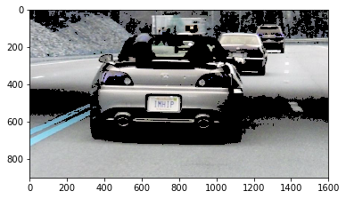

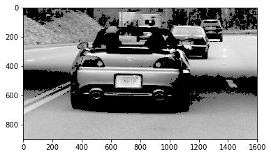

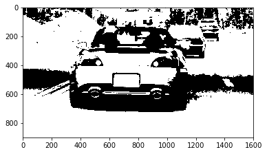

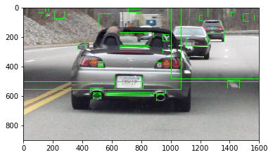

```
[ 0.31274992  0.68725008]
[ 0.38126598  0.61873402]
[ 0.08821239  0.91178761]
[ 0.06391238  0.93608762]
[ 0.04328282  0.95671718]
[ 0.14360177  0.85639823]
[ 0.07669435  0.92330565]
[ 0.09511834  0.90488166]
[ 0.09224261  0.90775739]
[ 0.09433215  0.90566785]
[ 0.00804643  0.99195357]
[ 0.05123869  0.94876131]
[ 0.09292093  0.90707907]
[ 0.06483149  0.93516851]
[ 0.19919351  0.80080649]
[ 0.24152999  0.75847001]
[ 0.23721157  0.76278843]
[ 0.23624636  0.76375364]
[ 0.05894277  0.94105723]
[ 0.75451942  0.24548058]
[ 0.29632944  0.70367056]
[ 0.15626942  0.84373058]
[ 0.22683819  0.77316181]
[ 0.03858834  0.96141166]
[ 0.83679188  0.16320812]
[ 0.24556561  0.75443439]
[ 0.31970316  0.68029684]
[ 0.07048195  0.92951805]
[ 0.04721967  0.95278033]
[ 0.02623548  0.97376452]
[ 0.10883838  0.89116162]
[ 0.02934661  0.97065339]
[ 0.27811114  0.72188886]
[ 0.22160539  0.77839461]
[ 0.33079677  0.66920323]
[ 0.19862904  0.80137096]
[ 0.10383343  0.89616657]
[ 0.07996549  0.92003451]
[ 0.03794212  0.96205788]
[ 0.04789279  0.95210721]
[ 0.52196483  0.47803517]
[ 0.0910422  0.9089578]
3
```

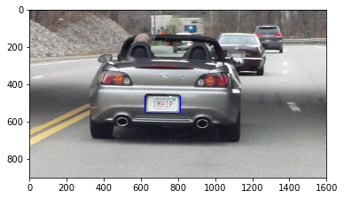

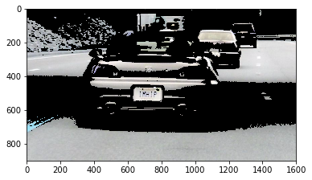

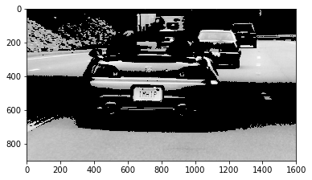

[8 more figures not shown]

```python
ranges = [50,100,150,200]
cropped_hits = []

for range in ranges:
    pimage, mask = preprocess(im, [range,range,range], [255, 255, 255])
    plt.imshow(pimage)
    plt.show()
    imgray = cv2.cvtColor(pimage,cv2.COLOR_BGR2GRAY)
    plt.imshow(imgray, cmap='gray')
    plt.show()
    flag, binaryImage = cv2.threshold(imgray, 85, 255, cv2.THRESH_BINARY + cv2.THRESH_OTSU)
    plt.imshow(binaryImage, cmap='gray')
    plt.show()
    im2, contours, hierarchy = cv2.findContours(binaryImage,cv2.RETR_TREE,cv2.CHAIN_APPROX_SIMPLE)
    copy = im.copy()
    rgb = cv2.cvtColor(copy, cv2.COLOR_BGR2RGB)
    boxes = [cv2.boundingRect(c) for c in contours]
    boxes2 = [b for b in boxes if b[2]*b[3] > 600]

    for x, y, w, h in boxes2:
        cv2.rectangle(rgb, (x,y),(x+w, y+h), (0, 255, 0), 2)
    plt.imshow(rgb)
    plt.show()

    def transform_scale(factor, boxes):
        return [[int(x[0]*factor), int(x[1]*factor), int(x[2]*factor), int(x[3]*factor)] for x in boxes]

    real_plates = []

    for x, y, w, h in boxes2:
        window = im[y:y+h, x:x+w, :3]
        window = cv2.resize(window, dims)
        feat = hog.compute(window)
        prob = svm.predict_proba(feat.reshape(1,-1))[0]
        print(prob)
        if prob[1] > .97:
            real_plates.append((x,y,w,h))

    print(len(real_plates))

    clone = im.copy()

    colors = [(0,255,0),(0,0,0),(255,0,255),(255,0,0),(255,165,0),(255,255,255), (1, 1, 1)]

    for x, y, w, h in real_plates:
        if w/h < 2.4 and w/h > 1.3:
            cv2.rectangle(clone, (x, y), (x+w, y+h), colors[3], 2)
            cropped_hits.append(im[y:y+h, x:x+w])

    plt.imshow(cv2.cvtColor(clone, cv2.COLOR_BGR2RGB))
    plt.show()
```

#### Save the most likely license plate images to folder 'hits' for Part 2.

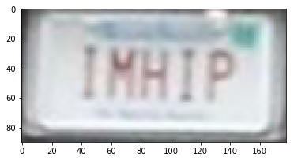

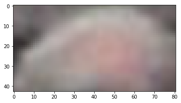

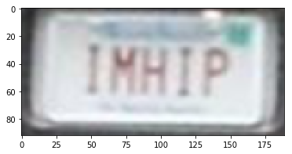

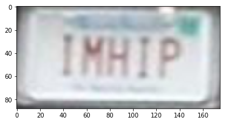

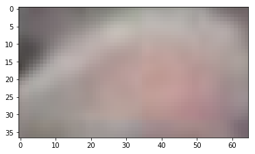

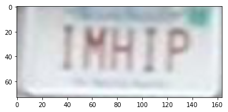

```python
i = 0

for hit in cropped_hits:
    s = 'hits/hit' + str(i) + '.png'
    plt.imshow(cv2.cvtColor(hit, cv2.COLOR_BGR2RGB))
    plt.show()
    cv2.imwrite(s,hit)
    i+=1
```